# Risk Factor Analysis

## Outcome Variable

**Outcome Variable:** pers_wasted624

## Predictor Variables

**Intervention Variable:** ever_sunderweight06

**Adjustment Set:**

- sex
- arm
- brthmon
- vagbrth
- single
- W_mage
- W_mhtcm
- W_mwtkg
- W_mbmi
- W_meducyrs
- W_feducyrs
- W_parity
- delta_brthmon
- delta_vagbrth
- delta_single
- delta_W_mage
- delta_W_mhtcm
- delta_W_mwtkg
- delta_W_mbmi
- delta_W_meducyrs
- delta_W_feducyrs
- delta_W_parity

## Stratifying Variables

The analysis was stratified on these variable(s):

- studyid
- country

## Data Summary

| studyid | country | ever_sunderweight06 | pers_wasted624 | n_cell | n | outcome_variable |
| --- | --- | --- | --- | --- | --- | --- |
| CMC-V-BCS-2002 | INDIA | 0 | 0 | 285 | 373 | pers_wasted624 |
| CMC-V-BCS-2002 | INDIA | 0 | 1 | 12 | 373 | pers_wasted624 |
| CMC-V-BCS-2002 | INDIA | 1 | 0 | 60 | 373 | pers_wasted624 |
| CMC-V-BCS-2002 | INDIA | 1 | 1 | 16 | 373 | pers_wasted624 |
| CMIN | BANGLADESH | 0 | 0 | 194 | 252 | pers_wasted624 |
| CMIN | BANGLADESH | 0 | 1 | 11 | 252 | pers_wasted624 |
| CMIN | BANGLADESH | 1 | 0 | 33 | 252 | pers_wasted624 |
| CMIN | BANGLADESH | 1 | 1 | 14 | 252 | pers_wasted624 |
| COHORTS | GUATEMALA | 0 | 0 | 904 | 1023 | pers_wasted624 |
| COHORTS | GUATEMALA | 0 | 1 | 20 | 1023 | pers_wasted624 |
| COHORTS | GUATEMALA | 1 | 0 | 78 | 1023 | pers_wasted624 |
| COHORTS | GUATEMALA | 1 | 1 | 21 | 1023 | pers_wasted624 |
| COHORTS | INDIA | 0 | 0 | 5698 | 6897 | pers_wasted624 |
| COHORTS | INDIA | 0 | 1 | 423 | 6897 | pers_wasted624 |
| COHORTS | INDIA | 1 | 0 | 428 | 6897 | pers_wasted624 |
| COHORTS | INDIA | 1 | 1 | 348 | 6897 | pers_wasted624 |
| COHORTS | PHILIPPINES | 0 | 0 | 2460 | 2809 | pers_wasted624 |
| COHORTS | PHILIPPINES | 0 | 1 | 154 | 2809 | pers_wasted624 |
| COHORTS | PHILIPPINES | 1 | 0 | 123 | 2809 | pers_wasted624 |
| COHORTS | PHILIPPINES | 1 | 1 | 72 | 2809 | pers_wasted624 |
| CONTENT | PERU | 0 | 0 | 213 | 215 | pers_wasted624 |
| CONTENT | PERU | 0 | 1 | 0 | 215 | pers_wasted624 |
| CONTENT | PERU | 1 | 0 | 2 | 215 | pers_wasted624 |
| CONTENT | PERU | 1 | 1 | 0 | 215 | pers_wasted624 |
| EE | PAKISTAN | 0 | 0 | 207 | 374 | pers_wasted624 |
| EE | PAKISTAN | 0 | 1 | 9 | 374 | pers_wasted624 |
| EE | PAKISTAN | 1 | 0 | 118 | 374 | pers_wasted624 |
| EE | PAKISTAN | 1 | 1 | 40 | 374 | pers_wasted624 |
| GMS-Nepal | NEPAL | 0 | 0 | 437 | 590 | pers_wasted624 |
| GMS-Nepal | NEPAL | 0 | 1 | 70 | 590 | pers_wasted624 |

[output cut: 90 more lines]

The following strata were considered:

- studyid: CMC-V-BCS-2002, country: INDIA
- studyid: CMIN, country: BANGLADESH
- studyid: COHORTS, country: GUATEMALA
- studyid: COHORTS, country: INDIA
- studyid: COHORTS, country: PHILIPPINES
- studyid: CONTENT, country: PERU
- studyid: EE, country: PAKISTAN
- studyid: GMS-Nepal, country: NEPAL
- studyid: Guatemala BSC, country: GUATEMALA
- studyid: IRC, country: INDIA
- studyid: JiVitA-3, country: BANGLADESH
- studyid: JiVitA-4, country: BANGLADESH
- studyid: Keneba, country: GAMBIA
- studyid: LCNI-5, country: MALAWI
- studyid: MAL-ED, country: BANGLADESH
- studyid: MAL-ED, country: BRAZIL
- studyid: MAL-ED, country: INDIA
- studyid: MAL-ED, country: NEPAL
- studyid: MAL-ED, country: PERU
- studyid: MAL-ED, country: SOUTH AFRICA
- studyid: MAL-ED, country: TANZANIA, UNITED REPUBLIC OF
- studyid: NIH-Birth, country: BANGLADESH
- studyid: NIH-Crypto, country: BANGLADESH
- studyid: PROBIT, country: BELARUS
- studyid: PROVIDE, country: BANGLADESH
- studyid: ResPak, country: PAKISTAN
- studyid: SAS-CompFeed, country: INDIA
- studyid: SAS-FoodSuppl, country: INDIA
- studyid: TanzaniaChild2, country: TANZANIA, UNITED REPUBLIC OF
- studyid: ZVITAMBO, country: ZIMBABWE

### Dropped Strata

Some strata were dropped due to rare outcomes:

- studyid: CONTENT, country: PERU
- studyid: Guatemala BSC, country: GUATEMALA
- studyid: MAL-ED, country: BANGLADESH
- studyid: MAL-ED, country: BRAZIL
- studyid: MAL-ED, country: NEPAL
- studyid: MAL-ED, country: PERU
- studyid: MAL-ED, country: SOUTH AFRICA
- studyid: MAL-ED, country: TANZANIA, UNITED REPUBLIC OF
- studyid: PROBIT, country: BELARUS

## Methods Detail

We’re interested in the causal parameters $E[Y_a]$ for all values of $a \in \mathcal{A}$. These parameters represent the mean outcome if, possibly contrary to fact, we intervened to set all units to have $A=a$. Under the randomization and positivity assumptions, these are identified by the statistical parameters $\psi_a=E_W[E_{Y|A,W}(Y|A=a,W)]$. In addition, we’re interested in the mean of $Y$, $E[Y]$ under no intervention (the observed mean). We will estimate these parameters by using SuperLearner to fit the relevant likelihood factors – $E_{Y|A,W}(Y|A=a,W)$ and $p(A=a|W)$, and then updating our likelihood fit using a joint TMLE.

For unadjusted analyses ($W=\{\}$), initial likelihoods were estimated using Lrnr_glm to estimate the simple $E(Y|A)$ and Lrnr_mean to estimate $p(A)$. For adjusted analyses, a small library containing Lrnr_glmnet, Lrnr_xgboost, and Lrnr_mean was used.

Having estimated these parameters, we will then use the delta method to estimate relative risks and attributable risks relative to a prespecified baseline level of $A$.

# Results Detail

## Results Plots

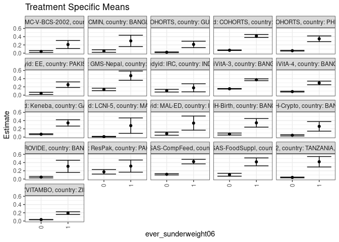

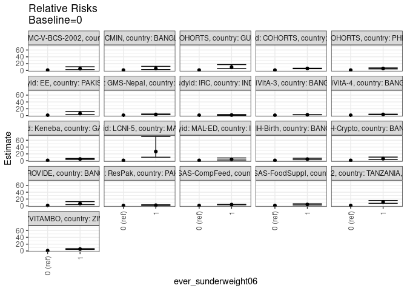

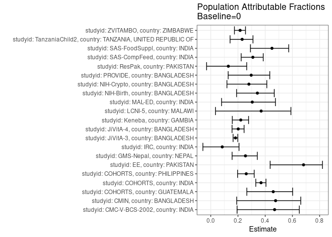

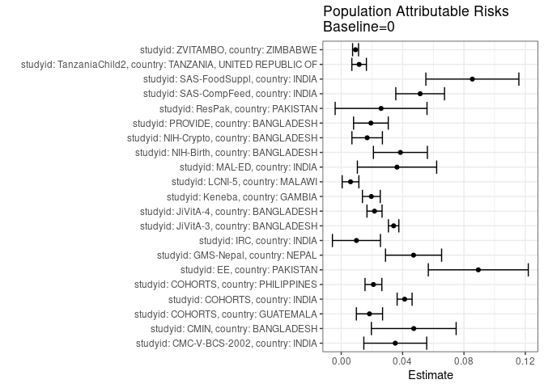

## Results Table

### Parameter: TSM

| studyid | country | intervention_level | baseline_level | estimate | ci_lower | ci_upper |
| --- | --- | --- | --- | --- | --- | --- |
| CMC-V-BCS-2002 | INDIA | 0 | NA | 0.0398490 | 0.0175439 | 0.0621541 |
| CMC-V-BCS-2002 | INDIA | 1 | NA | 0.2090338 | 0.1116965 | 0.3063712 |
| CMIN | BANGLADESH | 0 | NA | 0.0519284 | 0.0210820 | 0.0827748 |
| CMIN | BANGLADESH | 1 | NA | 0.2972471 | 0.1593296 | 0.4351647 |
| COHORTS | GUATEMALA | 0 | NA | 0.0216766 | 0.0122630 | 0.0310901 |
| COHORTS | GUATEMALA | 1 | NA | 0.2124313 | 0.1342085 | 0.2906540 |
| COHORTS | INDIA | 0 | NA | 0.0704797 | 0.0640111 | 0.0769483 |
| COHORTS | INDIA | 1 | NA | 0.4164244 | 0.3805564 | 0.4522924 |
| COHORTS | PHILIPPINES | 0 | NA | 0.0594707 | 0.0504279 | 0.0685135 |
| COHORTS | PHILIPPINES | 1 | NA | 0.3484158 | 0.2796122 | 0.4172194 |
| EE | PAKISTAN | 0 | NA | 0.0416667 | 0.0149824 | 0.0683509 |
| EE | PAKISTAN | 1 | NA | 0.2531646 | 0.1852731 | 0.3210560 |
| GMS-Nepal | NEPAL | 0 | NA | 0.1376002 | 0.1076309 | 0.1675694 |
| GMS-Nepal | NEPAL | 1 | NA | 0.4719746 | 0.3596259 | 0.5843233 |
| IRC | INDIA | 0 | NA | 0.1071755 | 0.0743810 | 0.1399700 |
| IRC | INDIA | 1 | NA | 0.1768254 | 0.0786941 | 0.2749568 |
| JiVitA-3 | BANGLADESH | 0 | NA | 0.1537624 | 0.1472630 | 0.1602618 |
| JiVitA-3 | BANGLADESH | 1 | NA | 0.3727907 | 0.3508313 | 0.3947502 |
| JiVitA-4 | BANGLADESH | 0 | NA | 0.0856647 | 0.0757176 | 0.0956118 |
| JiVitA-4 | BANGLADESH | 1 | NA | 0.2955875 | 0.2512385 | 0.3399365 |
| Keneba | GAMBIA | 0 | NA | 0.0692841 | 0.0588443 | 0.0797239 |
| Keneba | GAMBIA | 1 | NA | 0.3435018 | 0.2664192 | 0.4205844 |
| LCNI-5 | MALAWI | 0 | NA | 0.0102828 | 0.0031722 | 0.0173933 |
| LCNI-5 | MALAWI | 1 | NA | 0.2777778 | 0.0904991 | 0.4650565 |
| MAL-ED | INDIA | 0 | NA | 0.0827894 | 0.0446859 | 0.1208930 |
| MAL-ED | INDIA | 1 | NA | 0.3392143 | 0.1676822 | 0.5107464 |
| NIH-Birth | BANGLADESH | 0 | NA | 0.0739760 | 0.0500609 | 0.0978910 |
| NIH-Birth | BANGLADESH | 1 | NA | 0.3455290 | 0.2409908 | 0.4500672 |
| NIH-Crypto | BANGLADESH | 0 | NA | 0.0433722 | 0.0280337 | 0.0587108 |
| NIH-Crypto | BANGLADESH | 1 | NA | 0.2600903 | 0.1433676 | 0.3768130 |
| PROVIDE | BANGLADESH | 0 | NA | 0.0457023 | 0.0285874 | 0.0628172 |
| PROVIDE | BANGLADESH | 1 | NA | 0.3084261 | 0.1600774 | 0.4567748 |
| ResPak | PAKISTAN | 0 | NA | 0.1748788 | 0.1201447 | 0.2296129 |
| ResPak | PAKISTAN | 1 | NA | 0.3139814 | 0.1668407 | 0.4611222 |
| SAS-CompFeed | INDIA | 0 | NA | 0.1148618 | 0.0989402 | 0.1307834 |
| SAS-CompFeed | INDIA | 1 | NA | 0.4231323 | 0.3681306 | 0.4781339 |
| SAS-FoodSuppl | INDIA | 0 | NA | 0.1045214 | 0.0691536 | 0.1398892 |
| SAS-FoodSuppl | INDIA | 1 | NA | 0.4168750 | 0.3210590 | 0.5126910 |
| TanzaniaChild2 | TANZANIA, UNITED REPUBLIC OF | 0 | NA | 0.0388844 | 0.0303184 | 0.0474505 |
| TanzaniaChild2 | TANZANIA, UNITED REPUBLIC OF | 1 | NA | 0.4191446 | 0.2920510 | 0.5462382 |
| ZVITAMBO | ZIMBABWE | 0 | NA | 0.0339418 | 0.0304388 | 0.0374448 |
| ZVITAMBO | ZIMBABWE | 1 | NA | 0.1917649 | 0.1585094 | 0.2250204 |

### Parameter: E(Y)

| studyid | country | intervention_level | baseline_level | estimate | ci_lower | ci_upper |
| --- | --- | --- | --- | --- | --- | --- |
| CMC-V-BCS-2002 | INDIA | NA | NA | 0.0750670 | 0.0482904 | 0.1018437 |
| CMIN | BANGLADESH | NA | NA | 0.0992063 | 0.0622241 | 0.1361886 |
| COHORTS | GUATEMALA | NA | NA | 0.0400782 | 0.0280529 | 0.0521035 |
| COHORTS | INDIA | NA | NA | 0.1117877 | 0.1043506 | 0.1192249 |
| COHORTS | PHILIPPINES | NA | NA | 0.0804557 | 0.0703953 | 0.0905161 |
| EE | PAKISTAN | NA | NA | 0.1310160 | 0.0967738 | 0.1652583 |
| GMS-Nepal | NEPAL | NA | NA | 0.1847458 | 0.1534039 | 0.2160876 |
| IRC | INDIA | NA | NA | 0.1170732 | 0.0859146 | 0.1482317 |
| JiVitA-3 | BANGLADESH | NA | NA | 0.1879125 | 0.1813641 | 0.1944608 |
| JiVitA-4 | BANGLADESH | NA | NA | 0.1073532 | 0.0971813 | 0.1175251 |
| Keneba | GAMBIA | NA | NA | 0.0888980 | 0.0776057 | 0.1001903 |
| LCNI-5 | MALAWI | NA | NA | 0.0163317 | 0.0075211 | 0.0251422 |
| MAL-ED | INDIA | NA | NA | 0.1191489 | 0.0776405 | 0.1606574 |
| NIH-Birth | BANGLADESH | NA | NA | 0.1125461 | 0.0859151 | 0.1391771 |
| NIH-Crypto | BANGLADESH | NA | NA | 0.0602740 | 0.0429977 | 0.0775502 |
| PROVIDE | BANGLADESH | NA | NA | 0.0650407 | 0.0455353 | 0.0845460 |
| ResPak | PAKISTAN | NA | NA | 0.2008547 | 0.1494120 | 0.2522974 |
| SAS-CompFeed | INDIA | NA | NA | 0.1663067 | 0.1478935 | 0.1847199 |
| SAS-FoodSuppl | INDIA | NA | NA | 0.1900000 | 0.1515071 | 0.2284929 |
| TanzaniaChild2 | TANZANIA, UNITED REPUBLIC OF | NA | NA | 0.0505451 | 0.0409848 | 0.0601054 |
| ZVITAMBO | ZIMBABWE | NA | NA | 0.0432772 | 0.0394419 | 0.0471125 |

### Parameter: RR

| studyid | country | intervention_level | baseline_level | estimate | ci_lower | ci_upper |
| --- | --- | --- | --- | --- | --- | --- |
| CMC-V-BCS-2002 | INDIA | 0 | 0 | 1.000000 | 1.0000000 | 1.000000 |
| CMC-V-BCS-2002 | INDIA | 1 | 0 | 5.245646 | 2.5305569 | 10.873814 |
| CMIN | BANGLADESH | 0 | 0 | 1.000000 | 1.0000000 | 1.000000 |
| CMIN | BANGLADESH | 1 | 0 | 5.724173 | 2.7043155 | 12.116248 |
| COHORTS | GUATEMALA | 0 | 0 | 1.000000 | 1.0000000 | 1.000000 |
| COHORTS | GUATEMALA | 1 | 0 | 9.800042 | 5.5554379 | 17.287715 |
| COHORTS | INDIA | 0 | 0 | 1.000000 | 1.0000000 | 1.000000 |
| COHORTS | INDIA | 1 | 0 | 5.908431 | 5.2112271 | 6.698912 |
| COHORTS | PHILIPPINES | 0 | 0 | 1.000000 | 1.0000000 | 1.000000 |
| COHORTS | PHILIPPINES | 1 | 0 | 5.858609 | 4.5695507 | 7.511308 |
| EE | PAKISTAN | 0 | 0 | 1.000000 | 1.0000000 | 1.000000 |
| EE | PAKISTAN | 1 | 0 | 6.075949 | 3.0344655 | 12.165952 |
| GMS-Nepal | NEPAL | 0 | 0 | 1.000000 | 1.0000000 | 1.000000 |
| GMS-Nepal | NEPAL | 1 | 0 | 3.430044 | 2.4847433 | 4.734977 |
| IRC | INDIA | 0 | 0 | 1.000000 | 1.0000000 | 1.000000 |
| IRC | INDIA | 1 | 0 | 1.649868 | 0.8748693 | 3.111397 |
| JiVitA-3 | BANGLADESH | 0 | 0 | 1.000000 | 1.0000000 | 1.000000 |
| JiVitA-3 | BANGLADESH | 1 | 0 | 2.424460 | 2.2571097 | 2.604218 |
| JiVitA-4 | BANGLADESH | 0 | 0 | 1.000000 | 1.0000000 | 1.000000 |
| JiVitA-4 | BANGLADESH | 1 | 0 | 3.450517 | 2.8510564 | 4.176019 |
| Keneba | GAMBIA | 0 | 0 | 1.000000 | 1.0000000 | 1.000000 |
| Keneba | GAMBIA | 1 | 0 | 4.957875 | 3.7849635 | 6.494256 |
| LCNI-5 | MALAWI | 0 | 0 | 1.000000 | 1.0000000 | 1.000000 |
| LCNI-5 | MALAWI | 1 | 0 | 27.013889 | 10.2838431 | 70.960845 |
| MAL-ED | INDIA | 0 | 0 | 1.000000 | 1.0000000 | 1.000000 |
| MAL-ED | INDIA | 1 | 0 | 4.097314 | 2.0670365 | 8.121763 |
| NIH-Birth | BANGLADESH | 0 | 0 | 1.000000 | 1.0000000 | 1.000000 |
| NIH-Birth | BANGLADESH | 1 | 0 | 4.670828 | 2.9993007 | 7.273906 |
| NIH-Crypto | BANGLADESH | 0 | 0 | 1.000000 | 1.0000000 | 1.000000 |
| NIH-Crypto | BANGLADESH | 1 | 0 | 5.996699 | 3.3856074 | 10.621551 |
| PROVIDE | BANGLADESH | 0 | 0 | 1.000000 | 1.0000000 | 1.000000 |
| PROVIDE | BANGLADESH | 1 | 0 | 6.748589 | 3.6703967 | 12.408318 |
| ResPak | PAKISTAN | 0 | 0 | 1.000000 | 1.0000000 | 1.000000 |
| ResPak | PAKISTAN | 1 | 0 | 1.795423 | 1.0169114 | 3.169936 |
| SAS-CompFeed | INDIA | 0 | 0 | 1.000000 | 1.0000000 | 1.000000 |
| SAS-CompFeed | INDIA | 1 | 0 | 3.683838 | 3.0463197 | 4.454774 |
| SAS-FoodSuppl | INDIA | 0 | 0 | 1.000000 | 1.0000000 | 1.000000 |
| SAS-FoodSuppl | INDIA | 1 | 0 | 3.988418 | 2.6471812 | 6.009212 |
| TanzaniaChild2 | TANZANIA, UNITED REPUBLIC OF | 0 | 0 | 1.000000 | 1.0000000 | 1.000000 |
| TanzaniaChild2 | TANZANIA, UNITED REPUBLIC OF | 1 | 0 | 10.779234 | 7.4083727 | 15.683860 |
| ZVITAMBO | ZIMBABWE | 0 | 0 | 1.000000 | 1.0000000 | 1.000000 |
| ZVITAMBO | ZIMBABWE | 1 | 0 | 5.649813 | 4.6179277 | 6.912275 |

### Parameter: PAR

| studyid | country | intervention_level | baseline_level | estimate | ci_lower | ci_upper |
| --- | --- | --- | --- | --- | --- | --- |
| CMC-V-BCS-2002 | INDIA | 0 | NA | 0.0352180 | 0.0147228 | 0.0557133 |
| CMIN | BANGLADESH | 0 | NA | 0.0472779 | 0.0196483 | 0.0749076 |
| COHORTS | GUATEMALA | 0 | NA | 0.0184016 | 0.0098630 | 0.0269403 |
| COHORTS | INDIA | 0 | NA | 0.0413080 | 0.0364283 | 0.0461878 |
| COHORTS | PHILIPPINES | 0 | NA | 0.0209849 | 0.0154955 | 0.0264744 |
| EE | PAKISTAN | 0 | NA | 0.0893494 | 0.0567594 | 0.1219393 |
| GMS-Nepal | NEPAL | 0 | NA | 0.0471456 | 0.0288652 | 0.0654261 |
| IRC | INDIA | 0 | NA | 0.0098977 | -0.0057554 | 0.0255507 |
| JiVitA-3 | BANGLADESH | 0 | NA | 0.0341501 | 0.0307577 | 0.0375424 |
| JiVitA-4 | BANGLADESH | 0 | NA | 0.0216885 | 0.0167644 | 0.0266126 |
| Keneba | GAMBIA | 0 | NA | 0.0196139 | 0.0138073 | 0.0254205 |
| LCNI-5 | MALAWI | 0 | NA | 0.0060489 | 0.0006088 | 0.0114889 |
| MAL-ED | INDIA | 0 | NA | 0.0363595 | 0.0105160 | 0.0622030 |
| NIH-Birth | BANGLADESH | 0 | NA | 0.0385702 | 0.0209827 | 0.0561577 |
| NIH-Crypto | BANGLADESH | 0 | NA | 0.0169017 | 0.0069594 | 0.0268441 |
| PROVIDE | BANGLADESH | 0 | NA | 0.0193383 | 0.0080233 | 0.0306534 |
| ResPak | PAKISTAN | 0 | NA | 0.0259759 | -0.0039681 | 0.0559199 |
| SAS-CompFeed | INDIA | 0 | NA | 0.0514449 | 0.0355616 | 0.0673282 |
| SAS-FoodSuppl | INDIA | 0 | NA | 0.0854786 | 0.0551653 | 0.1157919 |
| TanzaniaChild2 | TANZANIA, UNITED REPUBLIC OF | 0 | NA | 0.0116606 | 0.0069136 | 0.0164077 |
| ZVITAMBO | ZIMBABWE | 0 | NA | 0.0093354 | 0.0074029 | 0.0112680 |

### Parameter: PAF

| studyid | country | intervention_level | baseline_level | estimate | ci_lower | ci_upper |
| --- | --- | --- | --- | --- | --- | --- |
| CMC-V-BCS-2002 | INDIA | 0 | NA | 0.4691542 | 0.1934567 | 0.6506111 |
| CMIN | BANGLADESH | 0 | NA | 0.4765617 | 0.1907507 | 0.6614299 |
| COHORTS | GUATEMALA | 0 | NA | 0.4591432 | 0.2649833 | 0.6020144 |
| COHORTS | INDIA | 0 | NA | 0.3695221 | 0.3308668 | 0.4059442 |
| COHORTS | PHILIPPINES | 0 | NA | 0.2608262 | 0.1972344 | 0.3193805 |
| EE | PAKISTAN | 0 | NA | 0.6819728 | 0.4362210 | 0.8206012 |
| GMS-Nepal | NEPAL | 0 | NA | 0.2551918 | 0.1568177 | 0.3420886 |
| IRC | INDIA | 0 | NA | 0.0845427 | -0.0578538 | 0.2077714 |
| JiVitA-3 | BANGLADESH | 0 | NA | 0.1817340 | 0.1641261 | 0.1989711 |
| JiVitA-4 | BANGLADESH | 0 | NA | 0.2020296 | 0.1564352 | 0.2451596 |
| Keneba | GAMBIA | 0 | NA | 0.2206339 | 0.1583243 | 0.2783306 |
| LCNI-5 | MALAWI | 0 | NA | 0.3703777 | 0.0352375 | 0.5890965 |
| MAL-ED | INDIA | 0 | NA | 0.3051602 | 0.0795749 | 0.4754572 |
| NIH-Birth | BANGLADESH | 0 | NA | 0.3427054 | 0.1897361 | 0.4667957 |
| NIH-Crypto | BANGLADESH | 0 | NA | 0.2804151 | 0.1191979 | 0.4121239 |
| PROVIDE | BANGLADESH | 0 | NA | 0.2973270 | 0.1277947 | 0.4339070 |
| ResPak | PAKISTAN | 0 | NA | 0.1293268 | -0.0306495 | 0.2644717 |
| SAS-CompFeed | INDIA | 0 | NA | 0.3093376 | 0.2237093 | 0.3855206 |
| SAS-FoodSuppl | INDIA | 0 | NA | 0.4498874 | 0.2912288 | 0.5730302 |
| TanzaniaChild2 | TANZANIA, UNITED REPUBLIC OF | 0 | NA | 0.2306978 | 0.1418998 | 0.3103069 |
| ZVITAMBO | ZIMBABWE | 0 | NA | 0.2157121 | 0.1740408 | 0.2552810 |